# PPOL670 | Applications in Unsupervised Machine Learning

Week 9

# Data

The Afghanistan Nationwide Quarterly Assessment Research (ANQAR) survey collects information from a subnational random sample of Afghan respondents from Sept. 2008 to May 2015 — resulting in a total of 32 survey waves. The survey gathers information on a variety of metrics, including for example, perceptions of the government, a respondent’s quality of life, the provision of services, and view on occupying forces in the country to name a few.

The ANQAR survey data randomly samples respondents from various administrative districts and provinces in Afghanistan across the relevant time period (see the ANQAR codebook for speciﬁc details on how the data was collected). There are a total of 426 districts where respondents are situated in 1 and 34 provinces housed in 7 broad regions.

The following data contains aggregated responses for questions regarding security for each district sampled during the survey’s initial wave around September 2008. 5 survey response questions (hereafter “items”) are retained in total. These items are

- **Q2**: How is the security situation in your mantaqa? Is it good, fair, or bad?
- **Q263**: How safe are the children in your village when they go to school and study in school? Are they completely safe, mostly safe, a little safe, a little unsafe, or very unsafe?
- **Q3**: Is security in your mantaqa better, the same or worse than it was 6 months ago? Is security in your mantaqa better, worse, or the same than it was 6 months ago?
- **Q4**: How safe do you feel traveling outside of your mantaqa during the day? Do you feel completely safe, mostly safe, a little safe, a little unsafe, or very unsafe?
- **Q5**: If you use roads in your district, how safe do you feel using the roads in your district? Do you feel completely safe, mostly safe, a little safe, a little unsafe, or very unsafe?

In addition, event data regarding the occurrence of violence within a Anfghan province is retained. The data on event occurrences was generated through reports of activity by the US army.

```r
dat <- read_csv('Data/afg-security-survey-2008.csv')
head(dat)
```

| province | district | year | event_count | occurrence | Q2 | Q263 | Q3 | Q4 | Q5 |
| --- | --- | --- | --- | --- | --- | --- | --- | --- | --- |
| 1 | 100 | 2008 | 5 | Violence | 1.30 | 2.800000 | 1.421053 | 2.90 | 3.400000 |
| 1 | 101 | 2008 | 5 | Violence | 1.60 | 1.100000 | 1.600000 | 1.70 | 2.300000 |
| 1 | 102 | 2008 | 5 | Violence | 1.30 | 2.450000 | 1.350000 | 2.30 | 3.300000 |
| 1 | 103 | 2008 | 5 | Violence | 1.70 | 2.500000 | 1.400000 | 2.10 | 3.200000 |
| 1 | 104 | 2008 | 5 | Violence | 1.95 | 2.210526 | 1.473684 | 2.55 | 3.315789 |
| 1 | 105 | 2008 | 5 | Violence | 1.00 | 3.100000 | 1.300000 | 2.50 | 3.100000 |

# Summarize

```r
skimr::skim(dat)
```

```
Skim summary statistics
 n obs: 244
 n variables: 10

── Variable type:character ───────────────────────────────────────────────────────────────────────────────────────────────────────────────────────────────
   variable missing complete   n min max empty n_unique
 occurrence       0      244 244   8  11     0        2

── Variable type:integer ─────────────────────────────────────────────────────────────────────────────────────────────────────────────────────────────────
    variable missing complete   n    mean     sd   p0     p25  p50     p75 p100     hist
    district       0      244 244  313.16 124.61  100  205.75  328  422.25  513 ▇▆▆▆▇▇▇▇
 event_count       0      244 244    3.45   2.51    0    1       4    5       8 ▇▂▂▃▆▂▂▂
    province       0      244 244   16.4    9.97    1    8      16   25      34 ▇▆▆▅▆▅▅▆
        year       0      244 244 2008      0    2008 2008    2008 2008    2008 ▁▁▁▇▁▁▁▁

── Variable type:numeric ─────────────────────────────────────────────────────────────────────────────────────────────────────────────────────────────────
 variable missing complete   n mean   sd  p0 p25  p50  p75 p100     hist
       Q2       0      244 244 1.13 0.42 0   0.9 1.15 1.4  2    ▁▂▃▅▇▆▃▂
     Q263       0      244 244 2.25 0.78 0.4 1.7 2.22 2.8  4    ▁▃▆▇▇▇▃▂
       Q3       0      244 244 1.01 0.36 0   0.8 1.05 1.26 1.8  ▁▂▃▅▇▇▃▂
       Q4       0      244 244 2.12 0.75 0   1.6 2.1  2.65 3.95 ▁▂▅▇▇▆▃▂
       Q5       0      244 244 2.82 0.88 0.6 2.2 2.79 3.4  4.8  ▁▂▅▇▇▆▂▂
```

# Scale Feautres

Just pull out the numerical values of interest

```r
features <- dat %>% select(contains("Q"))
ncol(features)
```

```
[1] 5
```

```r
skimr::skim(as.data.frame(features))
```

[output not shown]

# Principal Components

Calculate the principal components for each observation.

```r
pca_results <- PCA(features,graph=F)
```

Let’s examine the variance explained with a **Scree Plot** (remember: we’re looking for an elbow here).

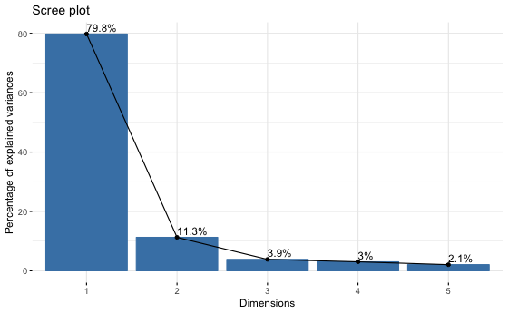

```r
fviz_eig(pca_results,
         addlabels = T)
```

For a more numerical representation. **What does this tell us?**

```r
get_eig(pca_results)
```

```
      eigenvalue variance.percent cumulative.variance.percent
Dim.1  3.9890531        79.781063                    79.78106
Dim.2  0.5634361        11.268723                    91.04979
Dim.3  0.1926007         3.852013                    94.90180
Dim.4  0.1513118         3.026236                    97.92803
Dim.5  0.1035983         2.071966                   100.00000
```

Roughly 80% of the variation can be explained with just one dimension!

Let’s now explore the data…

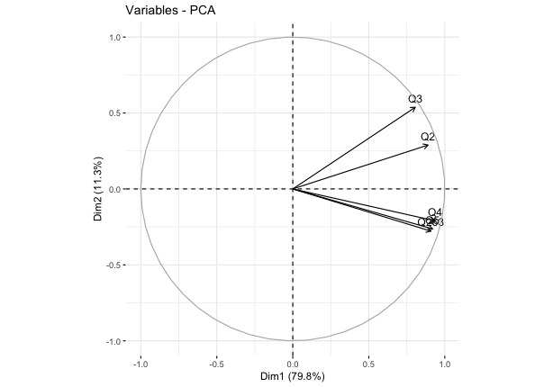

```r
fviz_pca_var(pca_results,axes = 1:2)
```

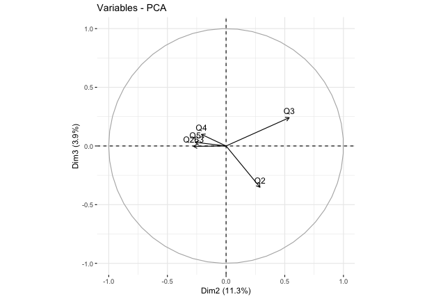

```r
fviz_pca_var(pca_results,axes = 2:3)
```

```r
scores = get_pca_ind(pca_results)
scores_dat <-  scores$coord
head(scores_dat)
```

```
        Dim.1      Dim.2      Dim.3       Dim.4       Dim.5
1  1.75886923  0.1984551  0.5920880  0.02324857 -0.18159149
2 -0.04091786  2.5263687 -0.1420030 -0.64612835 -0.07812049
3  1.04769222  0.4860552  0.2986683 -0.11062759  0.26463022
4  1.38132814  1.0444876 -0.4590236  0.01229062  0.35411093
5  1.90277664  1.3452386 -0.6779916 -0.50556459 -0.13012559
6  1.07134086 -0.1926349  0.8340850  0.65430391  0.12509206
```

```r
dat$score_1 <- scores_dat[,1]
dat$score_2 <- scores_dat[,2]
```

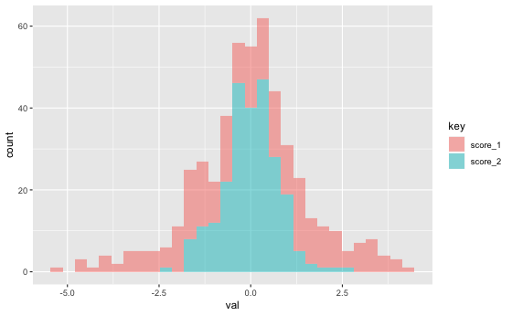

```r
dat %>%
  select(score_1,score_2) %>%
  gather(key,val) %>%
  ggplot(aes(val,fill=key)) +
  geom_histogram(alpha=.5)
```

Let’s plot the two axes against one another.

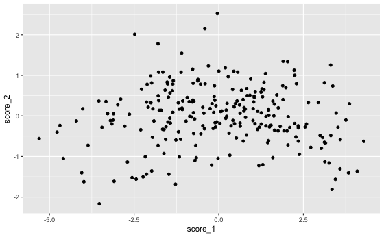

```r
dat %>%
  ggplot(aes(score_1,score_2)) +
  geom_point()
```

How do our concepts relate to the occurrence of conflict?

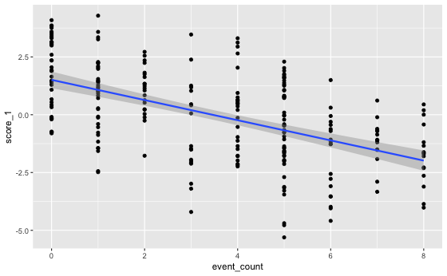

```r
dat %>%
  ggplot(aes(event_count,score_1)) +
  geom_point() +
  geom_smooth(method="lm")
```

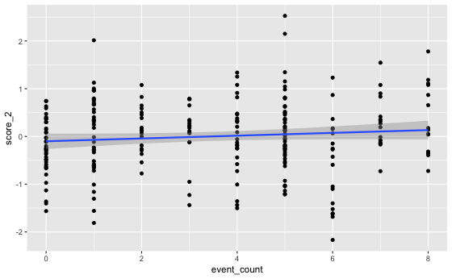

```r
dat %>%
  ggplot(aes(event_count,score_2)) +
  geom_point() +
  geom_smooth(method="lm")
```

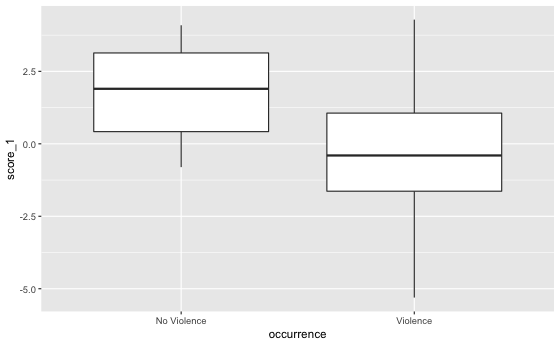

```r
dat %>%
  ggplot(aes(occurrence,score_1)) +
  geom_boxplot()
```

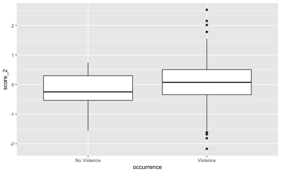

```r
dat %>%
  ggplot(aes(occurrence,score_2)) +
  geom_boxplot()
```

# K Means

Let’s now use the same data to try and cluster districts into groups.

```r
set.seed(123)
cluster1 = kmeans(features,centers = 3,nstart=20)

cluster1
```

```
K-means clustering with 3 clusters of sizes 76, 68, 100

Cluster means:
          Q2        Q263         Q3          Q4          Q5
1 -1.0639307 -0.98507695 -1.0407423 -1.04183984 -1.03605515
2  0.9837060  1.11973110  0.8059457  1.20213904  1.20608800
3  0.1396672 -0.01275867  0.2429211 -0.02565627 -0.03273792

Clustering vector:
  [1] 2 3 3 3 2 3 3 2 2 2 2 1 3 3 3 2 3 2 1 3 3 2 2 3 2 3 2 2 3 1 3 1 1 1 3 3 1 1 1 1 1 1 1 3 3 3 3 1 1 3 3 3 1 1 1 1 1 3 3 3 3 3 3 3 3 3 1 1 1 1 3 1 1 1
 [75] 3 1 3 1 3 3 2 2 3 1 1 3 3 3 1 3 3 3 3 3 3 3 3 1 3 1 3 3 1 2 2 2 2 3 2 2 2 3 3 2 3 2 3 3 3 3 3 3 3 2 3 2 2 2 2 3 3 3 2 2 2 2 2 2 2 1 3 2 3 2 2 2 2 3
[149] 1 2 2 3 2 2 2 2 3 3 2 2 2 3 3 2 2 3 3 3 3 1 1 1 1 1 1 3 1 1 3 1 3 1 1 1 1 1 1 1 3 1 1 2 3 1 3 1 1 1 3 3 1 3 3 1 1 3 1 1 3 1 1 3 1 3 1 1 1 1 1 1 3 1
[223] 3 1 3 2 2 2 2 2 2 2 2 2 2 2 2 2 1 3 2 3 2 3

Within cluster sum of squares by cluster:
[1] 161.7209 115.3550 131.3004
 (between_SS / total_SS =  66.4 %)

Available components:

[1] "cluster"      "centers"      "totss"        "withinss"     "tot.withinss" "betweenss"    "size"         "iter"         "ifault"
```

For information on the Total Withinness

```r
cluster1$tot.withinss
```

```
[1] 408.3763
```

Cluster Membership

```r
cluster1$cluster
```

```
  [1] 2 3 3 3 2 3 3 2 2 2 2 1 3 3 3 2 3 2 1 3 3 2 2 3 2 3 2 2 3 1 3 1 1 1 3 3 1 1 1 1 1 1 1 3 3 3 3 1 1 3 3 3 1 1 1 1 1 3 3 3 3 3 3 3 3 3 1 1 1 1 3 1 1 1
 [75] 3 1 3 1 3 3 2 2 3 1 1 3 3 3 1 3 3 3 3 3 3 3 3 1 3 1 3 3 1 2 2 2 2 3 2 2 2 3 3 2 3 2 3 3 3 3 3 3 3 2 3 2 2 2 2 3 3 3 2 2 2 2 2 2 2 1 3 2 3 2 2 2 2 3
[149] 1 2 2 3 2 2 2 2 3 3 2 2 2 3 3 2 2 3 3 3 3 1 1 1 1 1 1 3 1 1 3 1 3 1 1 1 1 1 1 1 3 1 1 2 3 1 3 1 1 1 3 3 1 3 3 1 1 3 1 1 3 1 1 3 1 3 1 1 1 1 1 1 3 1
[223] 3 1 3 2 2 2 2 2 2 2 2 2 2 2 2 2 1 3 2 3 2 3
```

Plot

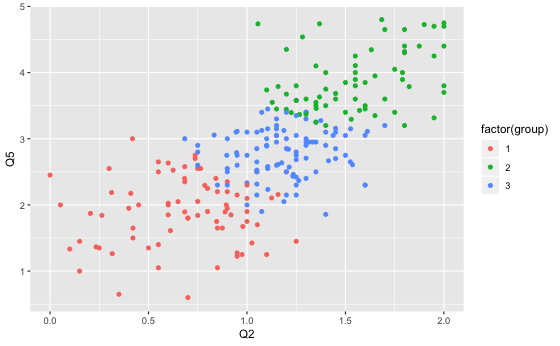

```r
dat$group = cluster1$cluster
ggplot(dat,aes(Q2,Q5,color=factor(group))) +
  geom_point()
```

Remember we want to select $k$ that minimizes the within variance…. but this value gets smaller and smaller as we expand the number of clusters…

```r
set.seed(123)
K = 3:100
W = rep(0,length(K))
for(i in 1:length(K)){
  clust = kmeans(features,centers = K[i],nstart = 20)
  W[i] = clust$tot.withinss
}
W
```

```
 [1] 408.37629 319.28228 282.15384 251.86127 235.64627 220.43255 206.47747 193.87195 181.75008 172.95114 165.48968 157.48172 152.35330 147.93812 142.86946
[16] 135.87807 131.57941 128.13422 125.10788 119.30173 117.65731 114.38653 109.40794 106.11626 104.01313 100.20606  97.69205  95.40143  91.80703  89.80543
[31]  88.62190  85.73825  84.32354  80.67732  79.50799  78.45573  75.50777  75.17447  73.43180  72.05361  70.21692  68.28455  68.08647  66.03693  65.27983
[46]  63.76120  62.03095  61.07269  60.81169  59.04371  57.02787  57.08150  56.56140  54.94088  54.34230  53.47791  52.18894  52.23434  51.18133  49.95425
[61]  48.53347  48.79807  47.52898  46.67611  46.05170  45.24707  44.45214  43.56675  42.63093  43.13828  41.76508  41.18284  40.56987  39.72297  39.84885
[76]  39.20841  37.79888  37.37629  37.10296  36.05505  35.74315  34.99073  35.32618  34.32068  34.00902  33.19205  33.17757  32.66245  32.08065  31.42572
[91]  30.23565  30.28761  30.01549  29.42111  29.04799  28.74146  28.50222  27.99554
```

# Hierarchical Clustering

To be more precise about how we’re clustering the data, let’s leverage what we know about Hierarchical clustering.

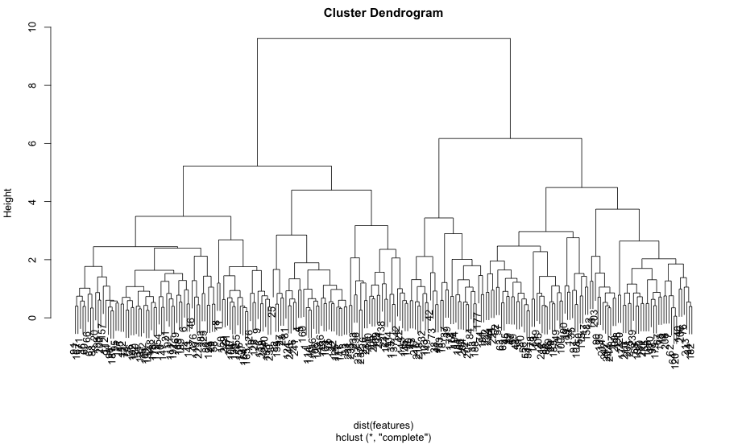

```r
hc_complete=hclust(dist(features), method="complete")
plot(hc_complete)
```

```r
# H for the height of the dendrogram that we want to cut
hc_complete_cut = cutree(hc_complete, h = 5)
hc_complete_cut
```

```
  [1] 1 2 1 1 1 3 2 3 3 3 3 2 2 3 3 1 2 3 2 3 3 1 1 1 1 3 1 1 3 2 3 4 4 2 2 3 4 4 4 4 4 4 4 2 2 3 2 2 2 2 2 2 2 2 2 2 2 3 2 3 3 2 2 2 2 3 2 2 2 2 3 4 4 4
 [75] 1 2 3 2 3 3 1 1 3 4 2 2 2 3 2 2 3 3 1 3 3 3 2 2 2 2 3 3 4 3 1 1 3 2 1 1 3 3 1 1 2 1 1 3 3 2 3 1 3 1 1 3 3 3 1 3 3 3 1 1 1 3 1 1 3 2 1 1 3 1 1 1 3 3
[149] 4 3 3 3 3 3 3 3 3 2 1 1 1 3 1 3 3 1 3 3 3 2 2 4 2 4 2 3 4 2 3 2 3 2 4 4 2 4 4 4 3 2 4 3 2 4 2 2 2 2 3 3 2 2 2 4 2 2 4 2 2 2 2 2 2 2 2 4 4 4 2 2 2 2
[223] 3 2 3 1 1 1 3 3 1 1 1 1 1 1 1 3 2 3 1 2 1 2
```

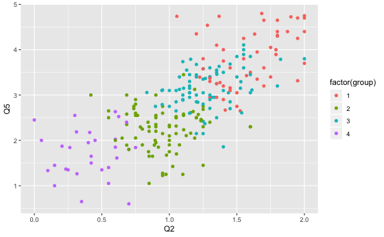

```r
dat$group = hc_complete_cut
ggplot(dat,aes(Q2,Q5,color=factor(group))) +
  geom_point()
```

Explore the other linkage methods.

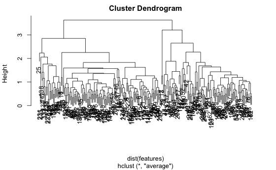

```r
hc_average=hclust(dist(features), method="average")
plot(hc_average)
```

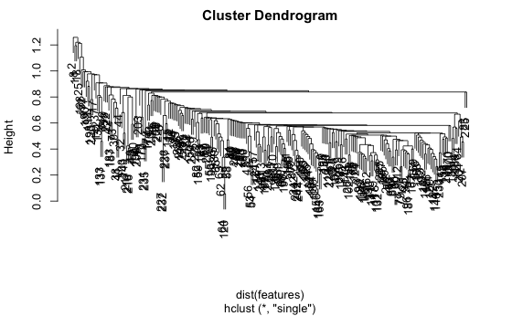

```r
hc_single=hclust(dist(features), method="single")
plot(hc_single)
```

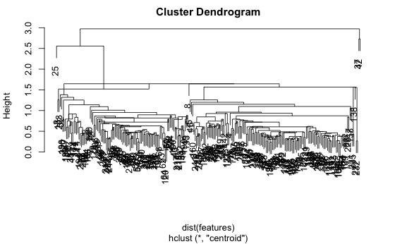

```r
hc_centroid=hclust(dist(features), method="centroid")
plot(hc_centroid)
```